# Concept Drift dectector - Mining Process Flotation Plant Database

#### Authors:

- Giménez López, Antonio
- Izquierdo Alvarez, Mario
- Ortega Pinto, Valentina Isabel de la Milagrosa
- Romero Romero, Martín

## Introduction

In this notebook, we will execute various concept drift detectors to verify the accuracy of our initial hypothesis. We will utilize the aggregated dataset for this purpose, as it is the dataset selected for training both batch and online learning models. It's important to note that the online learning method will employ the non-aggregated original dataset. However, the averages will be calculated dynamically, and only the data instances from the aggregated dataset will be used for training purposes.

## Importing the needed packages

First, is needed to add `utils/` to the syspath to use the custom functions

```python
import sys
import os
utils_path = os.path.abspath('../utils/')
if utils_path not in sys.path:
    sys.path.append(utils_path)
```

```python
from data_visualization import *
```

```python
from river import drift
import pandas as pd
from rich import print
import matplotlib.pyplot as plt

from tqdm import tqdm
```

## Loading prepared Data

This data has been taken from [Kaggle](https://www.kaggle.com/datasets/edumagalhaes/quality-prediction-in-a-mining-process) and has been previously **preprocessed** by aggregating by date and computing the **means** of the columns.

```python
# Loading data in a pandas DataFrame
csv_file_path = '../data/prepared_miningProcess_data_agg.csv'

df = pd.read_csv(csv_file_path)
```

```python
# Sorting data by date
df['date'] = pd.to_datetime(df['date'], format='%Y-%m-%d %H:%M:%S')

df = df.sort_values(by='date')
df
```

|  | date | % Iron Feed | % Silica Feed | Starch Flow | Amina Flow | Ore Pulp Flow | Ore Pulp pH | Ore Pulp Density | Flotation Column 01 Air Flow | Flotation Column 02 Air Flow | ... | Flotation Column 07 Air Flow | Flotation Column 01 Level | Flotation Column 02 Level | Flotation Column 03 Level | Flotation Column 04 Level | Flotation Column 05 Level | Flotation Column 06 Level | Flotation Column 07 Level | % Iron Concentrate | % Silica Concentrate |
| --- | --- | --- | --- | --- | --- | --- | --- | --- | --- | --- | --- | --- | --- | --- | --- | --- | --- | --- | --- | --- | --- |
| 0 | 2017-03-10 01:00:00 | 55.20 | 16.98 | 3162.625026 | 578.786678 | 398.753368 | 10.113487 | 1.729558 | 251.166672 | 250.226086 | ... | 250.208184 | 450.383776 | 446.891845 | 450.474523 | 449.912259 | 455.792161 | 464.383310 | 450.532747 | 66.91 | 1.31 |
| 1 | 2017-03-10 02:00:00 | 55.20 | 16.98 | 3133.256389 | 537.219661 | 399.871822 | 10.129742 | 1.667784 | 249.880589 | 250.214050 | ... | 249.897572 | 449.373361 | 450.249356 | 450.081222 | 450.328806 | 448.722983 | 455.501528 | 451.387700 | 67.06 | 1.11 |
| 2 | 2017-03-10 03:00:00 | 55.20 | 16.98 | 3479.482944 | 591.906744 | 398.763806 | 10.048403 | 1.732711 | 250.161328 | 250.104167 | ... | 250.484183 | 449.972878 | 450.868711 | 450.901822 | 451.145822 | 451.134189 | 459.981311 | 450.296722 | 66.97 | 1.27 |
| 3 | 2017-03-10 04:00:00 | 55.20 | 16.98 | 3228.036436 | 593.170106 | 399.866983 | 9.918614 | 1.731056 | 250.208772 | 250.204761 | ... | 250.157622 | 487.940706 | 491.462111 | 487.387206 | 494.528183 | 495.664011 | 502.763850 | 494.939889 | 66.75 | 1.36 |
| 4 | 2017-03-10 05:00:00 | 55.20 | 16.98 | 3327.280739 | 619.710806 | 399.615089 | 9.746029 | 1.765879 | 249.917800 | 250.160494 | ... | 250.078639 | 549.031539 | 549.983156 | 549.459572 | 549.975483 | 549.512533 | 560.696300 | 550.271772 | 66.63 | 1.34 |
| ... | ... | ... | ... | ... | ... | ... | ... | ... | ... | ... | ... | ... | ... | ... | ... | ... | ... | ... | ... | ... | ... |
| 4092 | 2017-09-09 19:00:00 | 49.75 | 23.20 | 3327.047776 | 497.211189 | 380.847200 | 9.176166 | 1.660871 | 301.565561 | 300.169133 | ... | 298.736661 | 397.781583 | 498.753311 | 403.858956 | 398.930467 | 502.971728 | 399.468911 | 400.559511 | 65.05 | 1.65 |
| 4093 | 2017-09-09 20:00:00 | 49.75 | 23.20 | 4225.800333 | 508.963856 | 381.112889 | 9.387541 | 1.691996 | 300.050172 | 299.967839 | ... | 303.599269 | 399.928567 | 499.648950 | 399.208611 | 399.967122 | 501.624533 | 398.905006 | 400.486233 | 64.83 | 1.71 |
| 4094 | 2017-09-09 21:00:00 | 49.75 | 23.20 | 2808.214692 | 517.748822 | 381.064411 | 9.771277 | 1.735647 | 299.814289 | 299.801561 | ... | 309.875439 | 399.961433 | 500.484917 | 471.827489 | 399.931033 | 500.223311 | 401.899806 | 400.556333 | 64.29 | 1.80 |
| 4095 | 2017-09-09 22:00:00 | 49.75 | 23.20 | 3191.497672 | 492.511228 | 380.445006 | 9.782121 | 1.716644 | 300.122756 | 299.679472 | ... | 305.254558 | 399.601383 | 498.614494 | 836.277192 | 400.455389 | 500.406239 | 402.703283 | 401.769072 | 64.25 | 1.96 |
| 4096 | 2017-09-09 23:00:00 | 49.75 | 23.20 | 3638.543653 | 460.769950 | 380.823147 | 9.653802 | 1.667826 | 299.778889 | 300.095394 | ... | 315.264733 | 400.026289 | 499.721794 | 868.549247 | 398.764744 | 500.682167 | 399.375644 | 398.775261 | 64.27 | 1.71 |

4097 rows × 24 columns

The concept drift detectors to be used, check for distribution changes on the data features. Thus, some columns need to be dropped: **date**, **% Iron Concentrate** and **% Silica Concentrate**

```python
# Drop the date and targets
features_to_monitor = df.columns.drop(['date', '% Iron Concentrate', '% Silica Concentrate'])
features_to_monitor
```

```
Index(['% Iron Feed', '% Silica Feed', 'Starch Flow', 'Amina Flow',
       'Ore Pulp Flow', 'Ore Pulp pH', 'Ore Pulp Density',
       'Flotation Column 01 Air Flow', 'Flotation Column 02 Air Flow',
       'Flotation Column 03 Air Flow', 'Flotation Column 04 Air Flow',
       'Flotation Column 05 Air Flow', 'Flotation Column 06 Air Flow',
       'Flotation Column 07 Air Flow', 'Flotation Column 01 Level',
       'Flotation Column 02 Level', 'Flotation Column 03 Level',
       'Flotation Column 04 Level', 'Flotation Column 05 Level',
       'Flotation Column 06 Level', 'Flotation Column 07 Level'],
      dtype='object')
```

## Using Adaptive Windowing method for concept drift detection

Adaptive Windowing method for concept drift detection.

Explanation taken from [River Documentation](https://riverml.xyz/dev/api/drift/ADWIN/)

```python
# Creating an ADWIN detector for each feature
detectors = {feature: drift.ADWIN() for feature in features_to_monitor}
changes = {feature: 0 for feature in features_to_monitor}
drifts_dict = {feature: [] for feature in features_to_monitor}
for index, row in df.iterrows():
    # Update the each deterctor and check for concept drift
    for feature in features_to_monitor:
        value = row[feature]
        detector = detectors[feature]
        detector.update(value)

        if detector.drift_detected:
            changes[feature] += 1
            drifts_dict[feature].append(index)
```

```python
for feature, drifts in changes.items():
    print(f"For feature {feature}, {drifts} drifts have been detected")
```

```
For feature % Iron Feed, 28 drifts have been detected
```

```
For feature % Silica Feed, 32 drifts have been detected
```

```
For feature Starch Flow, 17 drifts have been detected
```

```
For feature Amina Flow, 22 drifts have been detected
```

```
For feature Ore Pulp Flow, 6 drifts have been detected
```

```
For feature Ore Pulp pH, 8 drifts have been detected
```

```
For feature Ore Pulp Density, 2 drifts have been detected
```

```
For feature Flotation Column 01 Air Flow, 19 drifts have been detected
```

```
For feature Flotation Column 02 Air Flow, 26 drifts have been detected
```

```
For feature Flotation Column 03 Air Flow, 19 drifts have been detected
```

```
For feature Flotation Column 04 Air Flow, 18 drifts have been detected
```

```
For feature Flotation Column 05 Air Flow, 21 drifts have been detected
```

```
For feature Flotation Column 06 Air Flow, 18 drifts have been detected
```

```
For feature Flotation Column 07 Air Flow, 17 drifts have been detected
```

```
For feature Flotation Column 01 Level, 41 drifts have been detected
```

```
For feature Flotation Column 02 Level, 28 drifts have been detected
```

```
For feature Flotation Column 03 Level, 34 drifts have been detected
```

```
For feature Flotation Column 04 Level, 32 drifts have been detected
```

```
For feature Flotation Column 05 Level, 31 drifts have been detected
```

```
For feature Flotation Column 06 Level, 38 drifts have been detected
```

```
For feature Flotation Column 07 Level, 30 drifts have been detected
```

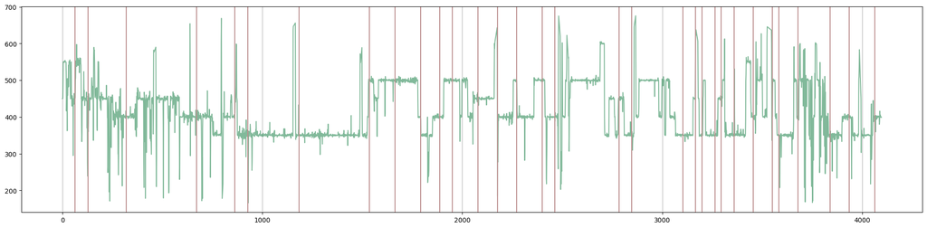

```python
feature =  'Flotation Column 04 Level'
plot_concept_drift(df[feature].values, drifts_dict[feature])
```

## Using Kolmogorov-Smirnov Windowing method for concept drift detection.

KSWIN (Kolmogorov-Smirnov Windowing) is a concept change detection method based on the Kolmogorov-Smirnov (KS) statistical test. The KS-test is a non-parametric test that does not assume any specific underlying data distribution. KSWIN is capable of monitoring data or performance distributions and requires the input to be one-dimensional arrays.

KSWIN operates by maintaining a sliding window of a fixed size (window_size). It considers the last stat_size samples within this window to represent the current concept. From the first portion of the window, a number of samples are uniformly drawn, representing an approximation of the current concept.

The KS-test is then applied to two windows of the same size. This test measures the distance between the empirical cumulative distributions of these windows.

A concept drift is detected by KSWIN if the difference in empirical data distributions between the two windows is significant, indicating that they do not originate from the same distribution.

Explanation taken from [River Documentation](https://riverml.xyz/dev/api/drift/KSWIN/)

```python
# Create a KSWIN detector per feature
detectors = {feature: drift.KSWIN() for feature in features_to_monitor}
changes = {feature: 0 for feature in features_to_monitor}
drifts_dict = {feature: [] for feature in features_to_monitor}

# Using tqdm for visulizing a progress bar.
for index, row in tqdm(df.iterrows(), total=df.shape[0]):
    for feature in features_to_monitor:
        value = row[feature]
        detector = detectors[feature]
        detector.update(value)

        if detector.drift_detected:
            changes[feature] += 1
            drifts_dict[feature].append(index)
```

```python
for feature, drifts in changes.items():
    print(f"For feature {feature}, {drifts} drifts have been detected")
```

```
For feature % Iron Feed, 31 drifts have been detected
```

```
For feature % Silica Feed, 30 drifts have been detected
```

```
For feature Starch Flow, 32 drifts have been detected
```

```
For feature Amina Flow, 36 drifts have been detected
```

```
For feature Ore Pulp Flow, 17 drifts have been detected
```

```
For feature Ore Pulp pH, 35 drifts have been detected
```

```
For feature Ore Pulp Density, 29 drifts have been detected
```

```
For feature Flotation Column 01 Air Flow, 19 drifts have been detected
```

```
For feature Flotation Column 02 Air Flow, 23 drifts have been detected
```

```
For feature Flotation Column 03 Air Flow, 21 drifts have been detected
```

```
For feature Flotation Column 04 Air Flow, 23 drifts have been detected
```

```
For feature Flotation Column 05 Air Flow, 22 drifts have been detected
```

```
For feature Flotation Column 06 Air Flow, 25 drifts have been detected
```

```
For feature Flotation Column 07 Air Flow, 21 drifts have been detected
```

```
For feature Flotation Column 01 Level, 34 drifts have been detected
```

```
For feature Flotation Column 02 Level, 31 drifts have been detected
```

```
For feature Flotation Column 03 Level, 37 drifts have been detected
```

```
For feature Flotation Column 04 Level, 34 drifts have been detected
```

```
For feature Flotation Column 05 Level, 32 drifts have been detected
```

```
For feature Flotation Column 06 Level, 35 drifts have been detected
```

```
For feature Flotation Column 07 Level, 32 drifts have been detected
```

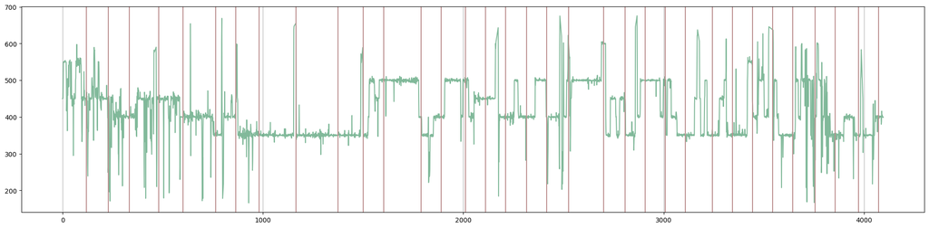

```python
feature =  'Flotation Column 04 Level'
plot_concept_drift(df[feature].values, drifts_dict[feature])
```

### Considerations

Once again, the above results show **several concept drift detections** at **each feature**, **supporting** both our **initial hypothesis** and the **ADWIN results**. Given these results, we can assume that **concept drift is present on our dataset**, thus, it can take **advantage** of **online learning capabilities**.

## Interactive histogram to visualize the evolution of '% Silica Concentrate' distribution

For visualization purposes, we have plotted the below **interactive** histogram. It allows seeing how the distribution of `% Silica Concentrate` **evolves**.

```python
concentrations = df['% Silica Concentrate']
plot_interactive_hist(concentrations, figsize=(20,10))
```

```
interactive(children=(IntSlider(value=1000, description='n', max=4097, min=1, step=1000), Output()), _dom_clas…
```